# 218Y_vivekvajipey_A4

With a significant portion of the Bay Area’s population living adjacent to the Bay, coastal flooding is projected to be a significant challenge in the near future. The effects of sea level rise can be compounded with intense storms, which can have widespread effects on coastal neighborhoods and roads. This analysis will focus on census block groups in the Friendly Acres, a well-off and dense suburban neighborhood of Redwood City. The location was selected for its proximity to the Bayshore Freeway and the existence of a buffer region between the bodies of water, such as Westpoint Slough and Redwood Creek, and the residences. A map displaying the selected census block groups can be seen below.

[interactive chart not shown]

We thought it would be interesting as it includes the freeway and will give potential insight to how the flood would impact transportation. It is also not immediately adjacent to the shore, so residents and policymakers may not be considering how sea level rise may impact them. Additionally, the area is mainly residential so later simplifying assumptions will be more accurate.

Our goal is to produce a hazard risk analysis in terms of vehicle damages corresponding to floods/sea level rise. Our analysis started by first processing flood maps for different hazard scenarios corresponding to different amounts of sea level rise and different recurrence intervals of floods. The example below shows the extent of an example 20-year flood where there was 50 centimeters of sea level rise.

Below we can see the extent of an example 20-year flood where there was 50cm of sea level rise.

[interactive chart not shown]

We then used OpenStreetMap data to find building footprints. These can be seen below. Note that we manually removed some clear non-residential buildings such as Taft Elementary School (the non-highlighted buildings in the middle of the purple residences).

[interactive chart not shown]

Using the flood maps and the building footprints, we then calculated the average depth of each building under each of the hazard scenarios.

To estimate vulnerability for vehicles, “percent damage” values from Table 3 of the Economic Guidance Memoranda 09-04 report were used. Note that we made the simplifying assumption that all the cars are sedans and used the corresponding values from the table. Since sedans have the highest estimated percent damage for a given depth, this will lead to a slight overestimate in damages. The relationship can be seen in the plot below.

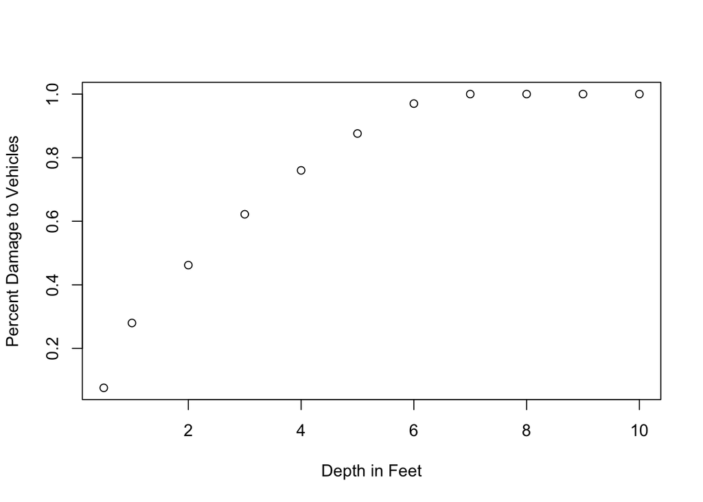

We then used EMFAC data to find percent increase of vehicles per decade. For the vehicle estimates, we assumed an even distribution of the population within each CBG as well as an even distribution of vehicles across all the residents. We also assumed that the vehicles are located at the ground level of the building they belong to.

Using this data and RCP 4.5 occurrence rates, we estimated average annualized loss in dollar amounts of vehicle damages from 2020 to 2050.

An additional assumption that we included in the annualized loss estimate is the average vehicle value for the area. Friendly Acres has a high average annual household income of $114,732 and based on listings for used cars in Redwood City, most of the vehicles in the area are valued between $25,000 and $50,000. Thus, an estimated average value of $35,000 per vehicle was used for the area. Additionally, the percent of vehicles that will be moved away from the hazard with advanced warning was estimated to be 25% because the Bayshore Freeway and other exit roads are likely to experience significant congestion due to the flooding and increased traffic due to cars leaving from other coastal cities.

Below we can see the average annualized loss mapped out to both per building and per CBG.

[interactive chart not shown]

The main takeaway here is that some residents of Friendly Acres will have to be saving upwards of $900,000 per year if they want to be prepared to pay for the predicted vehicle damages.

Additionally, in this region, there are 84 households with zero vehicles and 422 with only one vehicle. These households are uniquely vulnerable due to the fact that these households are likely to have a reliance on public transit or other alternative methods for transportation, which have a high chance of being shut down or being severely delayed due to the flooding.

This analysis of Friendly Acres has provided insight into the flood risk that threatens a dense residential neighborhood that is near the freeway and the Bay. Despite there being a sizable marsh that serves as a buffer region between the neighborhood and the coastline, the houses are still projected to incur losses due to flooding.